## Questions

**1. In which scenarios would it be best to consider dictionary-based approaches to text analysis? How does the decision to use dictionary-based approaches shape the research questions you can ask?**

```
Scenarios in which the research goals include the identification of specific topics, sentiment analysis, or more generally, detecting opinions or emotions around an issue are best for considering use of dictionary-based approaches. The scenario should also have a relevant and high-quality dictionary for best practice. Depending on what the goals of the research study is, using dictionary-based approaches affect the outcome variables of the research. For example, the research questions would now be centered around the categories that the dictionary-based approach identifies. If the analysis yields a valence score, the research question would be shaped around this spectrum. Additionally, because words in the dictionaries can have multiple meanings within different contexts and dialects of the same language, the research questions should also take that into consideration.
```

**2. Create a bar graph showing the frequencies of the twenty most-used tokens in our `senator_tweet_sample` corpus after removing URLs, stopwords, and “mentions” (cases where you see an “@” followed by non-whitespace characters - see Lab 8 example problems), but preserving hashtags as tokens (e.g. “#19thamendment” should be a single token). Now create a similar plot that ONLY includes the hashtags.**

Hint: you can do hashtag preservation in many ways, but you might find an easy solution by browsing the documentation for [`unnest_tokens`](https://www.rdocumentation.org/packages/tidytext/versions/0.2.6/topics/unnest_tokens) carefully.

```r
# identifying urls
url_pattern <- "(https?://|www\\.)\\S+"

# identifying hashtags
mention_pattern <- "@[A-Za-z0-9_]+"

# identifying hashtags
hashtag_pattern <- "#[A-Za-z0-9_]+"

hashtags <- senator_tweet_sample %>%
  mutate(word = str_extract_all(text, hashtag_pattern)) %>%
  unnest(word) %>%
  select(word) %>%
  count(word) %>%
  arrange(desc(n))

senator_tweet_sample <- senator_tweet_sample %>%
  mutate(cleaned = str_replace_all(text, paste0(url_pattern, "|", mention_pattern, "|", hashtag_pattern), ""))

# clean and bind hashtags
data(stop_words)
words <- senator_tweet_sample %>%
  unnest_tokens(word, cleaned) %>%
  anti_join(stop_words) %>%
  filter(word != "amp") %>%
  select(word) %>%
  count(word) %>%
  rbind(hashtags) %>%
  arrange(desc(n))
```

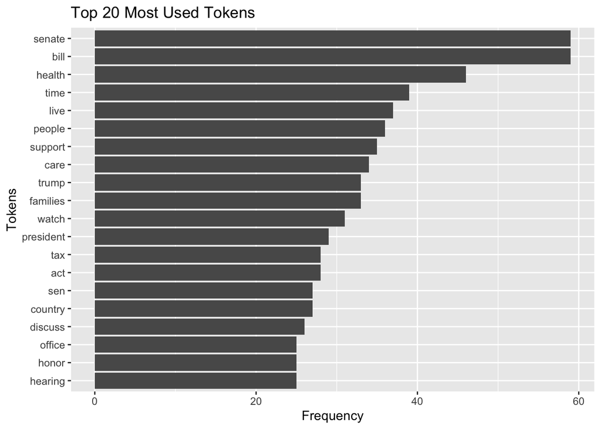

```r
words %>%
  head(20) %>%
  ggplot(aes(x = reorder(word, n), y = n)) +
  coord_flip() +
  geom_bar(stat='identity', position='dodge') +
  labs(title = "Top 20 Most Used Tokens",
       x = "Tokens",
       y = "Frequency")
```

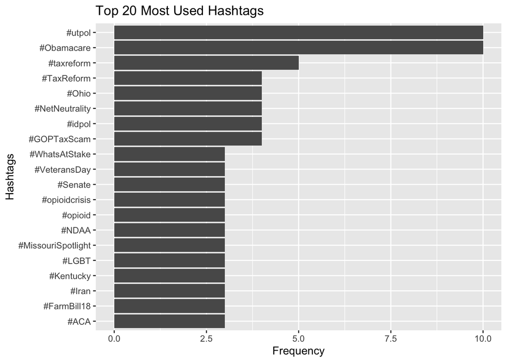

```r
hashtags %>%
  head(20) %>%
  ggplot(aes(x = reorder(word, n), y = n)) +
  coord_flip() +
  geom_bar(stat='identity', position='dodge') +
  labs(title = "Top 20 Most Used Hashtags",
       x = "Hashtags",
       y = "Frequency")
```

**3. For each of the top three most frequent non-stopword tokens, extract up to three tweets with the highest number of retweets that include the token. Based on the context provided in these Tweets, give a quick sentence about how they seem to be used and why they might appear frequently.**

```r
top_3 <- words %>% head(3)
senator_tweet_sample_sorted <- senator_tweet_sample %>% arrange(desc(retweet_count))

for (token in top_3$word) {
  temp <- senator_tweet_sample_sorted$text[grep(paste0("\\b", token, "\\b"), senator_tweet_sample_sorted$text, ignore.case = TRUE)] %>% head(3)
  print(paste0("-------------- TOKEN: ", token, " --------------"))
  print(temp)
  print("----------------------------")
}
```

```
## [1] "-------------- TOKEN: bill --------------"
## [1] "Here is a new summary of the health bill the Senate is considering passing.\n\nRT if helpful. https://t.co/EHlBf158AL"
## [2] "Sound the alarm! Senate Republicans’ tax-cut bill is now an attack on the Affordable Care Act. 13 million people will lose their health coverage if this passes! #GOPTaxPlan"
## [3] "No help from Dems? R's crafted a bill in secret w/no public hearings &amp; will skip committee review. Open up the process! #PeopleNotPolitics https://t.co/6dKn5Lf9ew"
## [1] "----------------------------"
## [1] "-------------- TOKEN: senate --------------"
## [1] "Here is a new summary of the health bill the Senate is considering passing.\n\nRT if helpful. https://t.co/EHlBf158AL"
## [2] "Under President Obama, Democrats have lost 900+ state legislature seats, 12 governors, 69 House seats, 13 Senate seats. That's some legacy."
## [3] "Sound the alarm! Senate Republicans’ tax-cut bill is now an attack on the Affordable Care Act. 13 million people will lose their health coverage if this passes! #GOPTaxPlan"
## [1] "----------------------------"
## [1] "-------------- TOKEN: health --------------"
## [1] "Here is a new summary of the health bill the Senate is considering passing.\n\nRT if helpful. https://t.co/EHlBf158AL"
## [2] "Cases that may make it to the Supreme Court:\n\nComprehensive health care coverage for nursing mothers\nFalse advertising by insurance companies about access to doctors\nRequirements that wealthy corporations provide health care coverage to their workers \n\n#WhatsAtStake"
## [3] "Sound the alarm! Senate Republicans’ tax-cut bill is now an attack on the Affordable Care Act. 13 million people will lose their health coverage if this passes! #GOPTaxPlan"
## [1] "----------------------------"
```

[output not shown]

**4. Use TF-IDF to show the top 10 words that are most distinctive to Tweets published by Males and Females as a bar chart. To do this, you may combine texts from all Tweets published by these two genders, essentially treating our corpus as being two “documents” in the terminology that TF-IDF methods typically use. This approach provides a systematic way of comparing large number of texts along any dimension of interest.**

```r
# identifying urls
url_pattern <- "(https?://|www\\.)\\S+"

# identifying hashtags
mention_pattern <- "@[A-Za-z0-9_]+"

senator_tweet_sample <- senator_tweet_sample %>%
    mutate(screen_name = tolower(screen_name))

social_media_and_gender <- congress %>%
  left_join(congress_contact, by = "bioguide_id") %>%
  subset(type == "sen") %>%
  mutate(twitter = tolower(twitter)) %>%
  right_join(senator_tweet_sample, by = c("twitter" = "screen_name")) %>%
  mutate(text = str_remove_all(text, url_pattern)) %>% # remove urls
  mutate(text = str_remove_all(text, mention_pattern)) # remove mentions

data(stop_words)
gender_tweets <- social_media_and_gender %>%
  select(gender, text) %>%
  unnest_tokens("word", text) %>%
  anti_join(stop_words) %>%
  count(word, gender) %>%
  bind_tf_idf(word, gender, n)
```

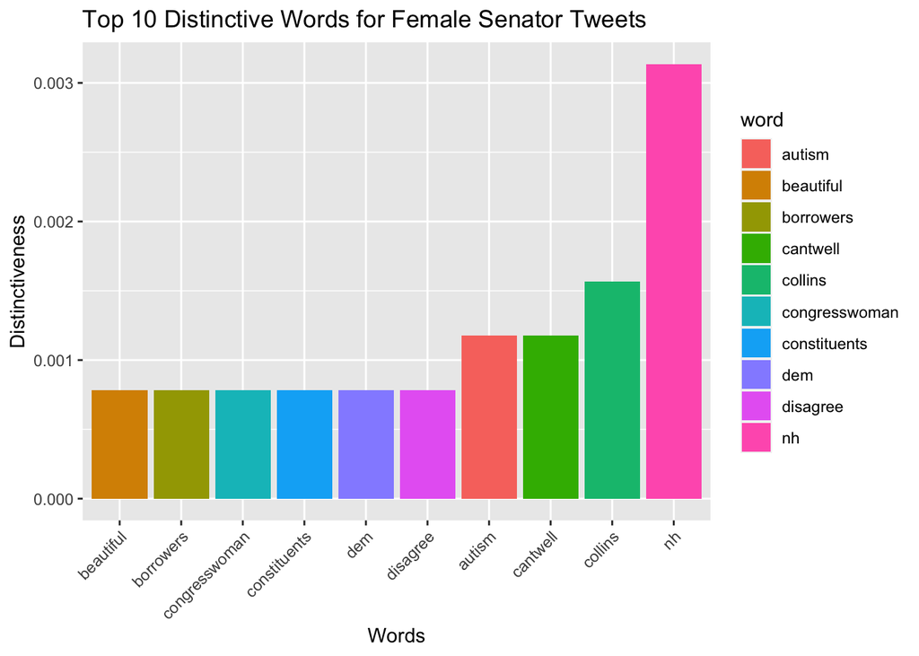

```r
f_tweets <- gender_tweets %>%
  subset(gender == "F")

m_tweets <- gender_tweets %>%
  subset(gender == "M")

f_tweets %>%
  arrange(desc(tf_idf)) %>%
  head(10) %>%
  ggplot(aes(x = reorder(word, tf_idf), y = tf_idf, fill = word)) +
  geom_bar(stat='identity', position='dodge') +
  labs(title = "Top 10 Distinctive Words for Female Senator Tweets",
       x = "Words",
       y = "Distinctiveness") +
  theme(axis.text.x = element_text(angle = 45, hjust = 1))
```

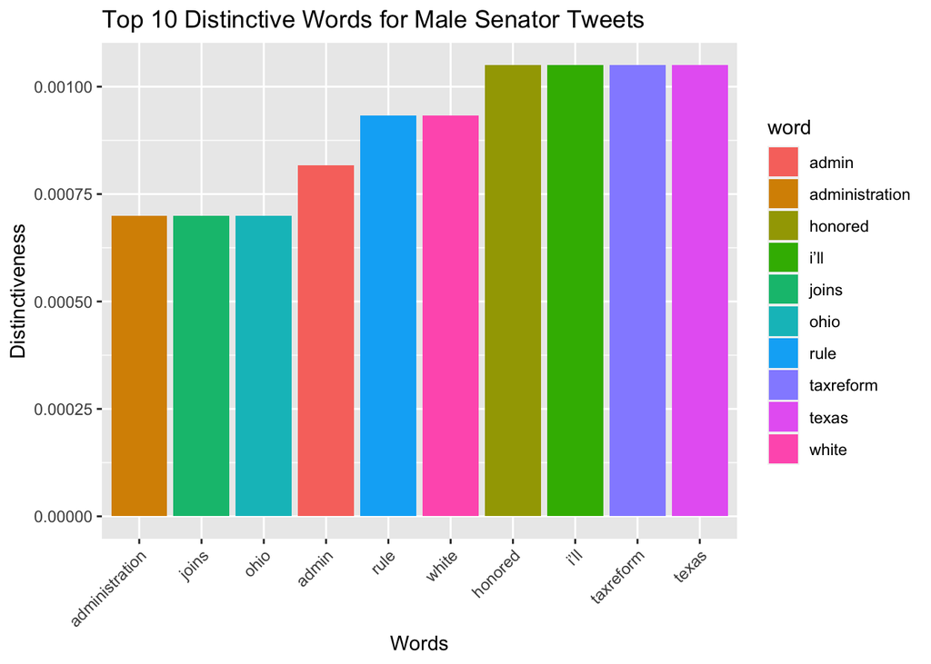

```
N/A
```

```r
m_tweets %>%
  arrange(desc(tf_idf)) %>%
  head(10) %>%
  ggplot(aes(x = reorder(word, tf_idf), y = tf_idf, fill = word)) +
  geom_bar(stat='identity', position='dodge') +
  labs(title = "Top 10 Distinctive Words for Male Senator Tweets",
       x = "Words",
       y = "Distinctiveness") +
  theme(axis.text.x = element_text(angle = 45, hjust = 1))
```

**5. Create a new column in senator_tweet_sample that corresponds to the time of day that a given tweet was posted, and make a bar graph comparing the number of tweets published in daytime (5am-5pm, inclusive) vs night.**

Hint: see the `hour` function of lubridate.

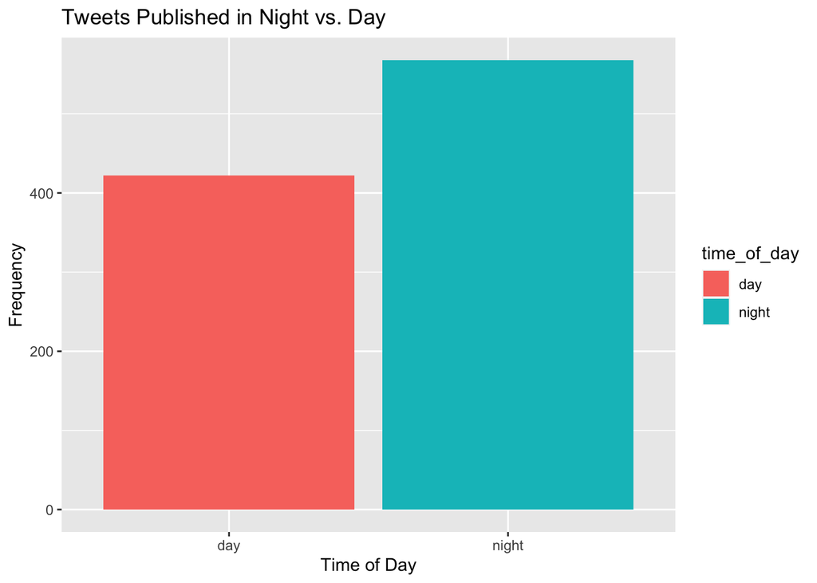

```r
senator_tweet_sample <- senator_tweet_sample %>%
  mutate(time_of_day = if_else(hour(created_at) >= 5 & hour(created_at) <= 17, "day", "night"))

senator_tweet_sample %>%
  count(time_of_day) %>%
  ggplot(aes(x = time_of_day, y = n, fill = time_of_day)) +
  geom_bar(stat='identity', position='dodge') +
  labs(title = "Tweets Published in Night vs. Day",
       x = "Time of Day",
       y = "Frequency")
```

**6. Use the “bing” sentiment dictionary to compare the average sentiment for Tweets published in daytime vs nighttime using a bar plot. You get to choose how you will create these sentiment scores for comparison - explain and justify your decision. Also explain your interpretation of the results.**

HINT: use `get_sentiments("bing")` to get the Bing dictionary.

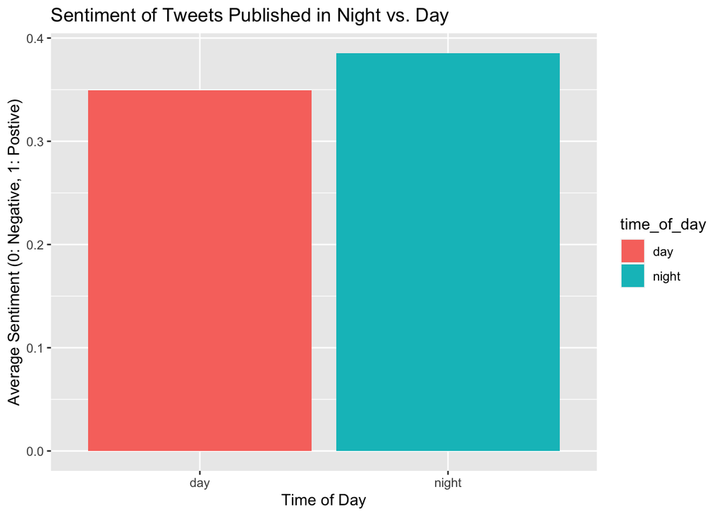

[output not shown]

```r
sentiments <- get_sentiments("bing")

# Define the function
calculate_sentiment_score <- function(text) {
  tokens <- tibble(text = text) %>%
    unnest_tokens(word, text)

  sentiment_scores <- tokens %>%
    inner_join(sentiments, by = "word")

  positive_count <- sum(sentiment_scores$sentiment == "positive", na.rm = TRUE)
  negative_count <- sum(sentiment_scores$sentiment == "negative", na.rm = TRUE)

  return((positive_count - negative_count) / nrow(sentiment_scores))
}

sentiment_tweets <- senator_tweet_sample %>%
  rowwise() %>%
  mutate(sentiment = calculate_sentiment_score(text))

sentiment_tweets %>%
  group_by(time_of_day) %>%
  summarise(proportion_sentiment = mean(sentiment, na.rm = TRUE)) %>%
  ggplot(aes(x = time_of_day, y = proportion_sentiment, fill = time_of_day)) +
  geom_bar(stat='identity', position='dodge') +
  labs(title = "Sentiment of Tweets Published in Night vs. Day",
       x = "Time of Day",
       y = "Average Sentiment (0: Negative, 1: Postive)")
```

**7. Create a custom dictionary with at least two categories (e.g. positive/negative, happy/sad, solution/problem-oriented, etc) and compare daytime-nightime scores for each of the two categories. What does this result tell you about your data? What is your dictionary capturing here?**

Hint: you may want to look at the bing dictionary (`get_sentiments("bing")`) to see how you should format your custom dictionary.

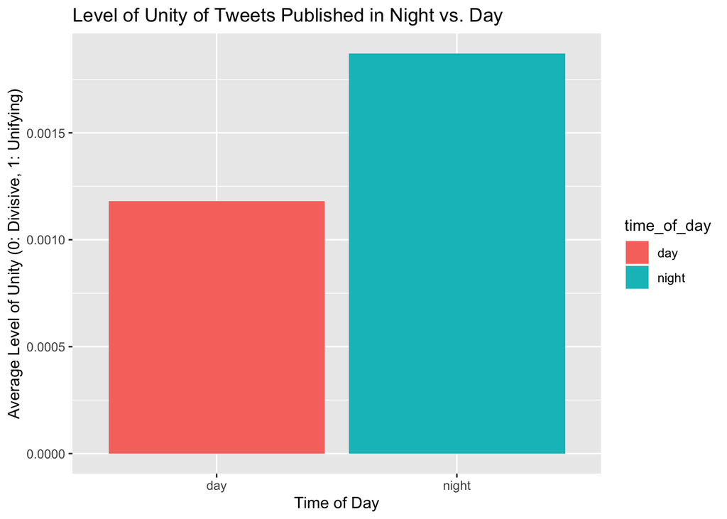

[output not shown]

```r
custom_topic_dict <- data.frame(
  word=c('bipartisan', 'together', ' agree', 'solidarity', 'divisive', 'wrong', 'disagree', 'fail'), # list of words
  category=c('unity', 'unity', 'unity', 'unity', 'division', 'division', 'division', 'division') # list of categories associated with each word
)

calculate_sentiment_score <- function(text) {
  tokens <- tibble(text = text) %>%
    unnest_tokens(word, text)

  sentiment_scores <- tokens %>%
    left_join(custom_topic_dict, by = "word")

  positive_count <- sum(sentiment_scores$category == "unity", na.rm = TRUE)
  negative_count <- sum(sentiment_scores$category == "division", na.rm = TRUE)

  return((positive_count - negative_count) / nrow(sentiment_scores))
}

polarizing_tweets <- senator_tweet_sample %>%
  rowwise() %>%
  mutate(sentiment = calculate_sentiment_score(text))

polarizing_tweets %>%
  group_by(time_of_day) %>%
  summarise(proportion_sentiment = mean(sentiment, na.rm = TRUE)) %>%
  ggplot(aes(x = time_of_day, y = proportion_sentiment, fill = time_of_day)) +
  geom_bar(stat='identity', position='dodge') +
  labs(title = "Level of Unity of Tweets Published in Night vs. Day",
       x = "Time of Day",
       y = "Average Level of Unity (0: Divisive, 1: Unifying)")
```

**8. Using the data you have collected for your final project, show one preliminary result or statistic from an analysis you ran. If you haven’t collected your dataset computationally, try to look anecdotally at the original source (e.g. if Twitter is your dataset, then just look on the Twitter website) and give one observation about the data. Try to make an observation or result based on one of the variables you will use for your final analysis. What do you see? Please send your figures and statistics directly to your TA in Slack - don’t add them to your script.**

[output not shown]